# Quinn Reserach Group Fall '18 Presentation

## Christian McDaniel

### Developing a Start-to-Finish Pipeline for Accelerometer-Based Activity Recognition Using Long Short-Term Memory Recurrent Neural Networks

### Christian McDaniel and Shannon Quinn

#### *SciPy 2018 Conference Proceedings*

# Presentation Roadmap:

1. Background - Title Breakdown
   1. Accelerometer-Based Activity Recognition
      - What
      - Why
      - How
   2. Using Long Short-Term Memory Recurrent Neural Networks
      - What
      - Why
      - How
   3. Developing a Start-to-Finish Pipeline
2. Related Works - A Glimpse at the Field
3. Methods
4. Results, Conclusion

# Developing a Start-to-Finish Pipeline for Accelerometer-Based Activity Recognition Using Long Short-Term Memory Recurrent Neural Networks

## Christian McDaniel and Shannon Quinn

### SciPy 2018 Conference Proceedings

### That's a loot of words... lets break it down

# "Accelerometer-Based Activity Recognition"

# "Accelerometer-Based Activity Recognition"

### 1) The "What"

# "Accelerometer-Based Activity Recognition"

### 2) The "Why"

|  | From Human Health (HAR).... To Machine Health (LOL) |  |
| --- | --- | --- |
| 1998 |  | 2018 |

# "Accelerometer-Based Activity Recognition"

### 2) The "Why"

Activities of Daily Life (ADL):

# "Accelerometer-Based Activity Recognition"

### 2) The "Why"

Clinical Diagnosis:

| Parkinson's Disease (Motor SXs) | Nighttime Scratching |
| --- | --- |

# "Accelerometer-Based Activity Recognition"

### 2) The "Why"

Fill in the Blank:

| XCS | Driver Training and Industry Training | ASL |
| --- | --- | --- |

# "Accelerometer-Based Activity Recognition"

### 3) The "How"

###### Key Points:

> Classical vs. AI

> Online/ On-Device vs. *post hoc* analysis

[figure not shown]

... which brings us to ...

# "Using Long Short-Term Memory Recurrent Neural Networks"

# "Using Long Short-Term Memory Recurrent Neural Networks"

### 1) The "What" - **Artificial Neural Networks**

# "Using Long Short-Term Memory Recurrent Neural Networks"

### 1) The "What" - Artificial Neural Networks

[figure not shown]

# General Training Pipeline:

1. Conduct a forward pass,
   - compute y ̃ and compare with y to generate the error term
2. Backpropagate the error regarding the correction needed for y ̃
3. Backpropagate the correction to the hidden layer
4. update weight matrices A and B via dy and dz

[figure not shown]

# Bias - Variance Tradeoff

# Bias - Variance Tradeoff

## These networks are very flexible!

# Bias - Variance Tradeoff

## These networks are very flexible!

### And very capable of overfitting the data

| _ | _ |
| --- | --- |

# Bias - Variance Tradeoff

## These networks are very flexible!

### And very capable of overfitting the data

### Not to mention, going deeper has led to issues (i.e., exploding and vanishing gradients)

[figure not shown]

- e.g., the magnitude of the update gets smaller as the error gradient is backpropagated to shallower layers

### Some methods to help with this:

- `Early Stopping` | `Weight Decay` | `Dropout` | `Learning Rate` | `Norm Regularization` | `Gradient Clipping` | `Batch Normalization`

# And there's the issue of having *time series* data

| This data |  | This data |
| --- | --- | --- |
|  | ... Is a bit different than ... |  |

# "Using Long Short-Term Memory Recurrent Neural Networks"

### 1) The "What" - **Recurrent Neural Networks**

# "Using Long Short-Term Memory Recurrent Neural Networks"

### 1) The "What" - Recurrent Neural Networks

[figure not shown]

## Each neuron now has TWO sets of weights:

#### y(t) = φ(Wx ·x(t) +Wy ·Y(t−1) +b)

### Backpropagation is performed on the "unrolled" neuron,

#### i.e., **"Back Propagation Through Time" (BPTT)**

[figure not shown]

### Backpropagation is performed on the "*unrolled*" neuron, i.e., **"Back Propagation Through Time" (BPTT)**

### This causes the networks to become *very* deep *very* quickly

#### depth = n timesteps per input per layer

## Re-enter: Exploding and Vanishing Gradients

- As the gradient is back-propagated, its influence on the weight matrix at a given layer decreases "through time"

[figure not shown]

# "Using Long Short-Term Memory Recurrent Neural Networks"

### 1) The "What" - **The Long Short-Term Memory Cell**

# "Using Long Short-Term Memory Recurrent Neural Networks"

### 1) The "What" - The Long Short-Term Memory Cell

[figure not shown]

**Inputs:** `x(t)` = single time-step fed into 4 independent fully-connected layers `h(t)` = short-term state `c(t)` = long-term state

# Gates:

- each gate is essentially its own neuron / perceptron
  - input * weight, add a bias, activate!

## Why?

- The gates work together to modulate the Attention Mechanism
- f(t): foget gate / remember vector
  - binary decision to drop or retain the input it receives
- i(t): input gate / save vector
  - how much of input to allow into the cell state
- o(t): output gate / attention mechanism
  - what part of information should the neuron be focusing on

```python
# let's look into the lstm cell using only numpy!
import numpy as np
# and matplotlib to see some of what we're doing :)
import matplotlib.pyplot as plt
import seaborn as sns

%matplotlib inline
```

```python
# first let's set up our activation functions
def sigmoid(x):
        return 1 / (1 + np.exp(-x))
```

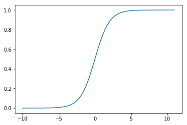

```python
# let's plot that to see what we've made
example = np.arange(-10,11, .01)
plt.plot(example, sigmoid(example))
```

```python
# now for tanh, another function in the exponential family with a bit different output range
def g(x):
    return np.exp(x) / (1 + np.exp(x))

def tanh_1(x):
    return (2*g(2*x))-1

def tanh_2(x):
    return (np.exp(x)-np.exp(-x)) / (np.exp(x)+np.exp(-x))

def tanh_3(x):
    return np.tanh(x)
```

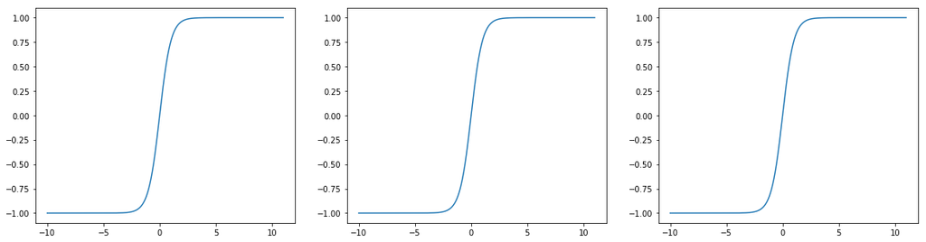

```python
# and to plot:
plt.figure(figsize=(20,5))
plt.subplot(1,3,1)
plt.plot(example, tanh_1(example))
plt.subplot(1,3,2)
plt.plot(example, tanh_2(example))
plt.subplot(1,3,3)
plt.plot(example, tanh_3(example))
```

```
array([-0.08557031,  0.19866981,  1.11648423, ..., -0.00834961,
       -0.00971766, -0.00373537])
```

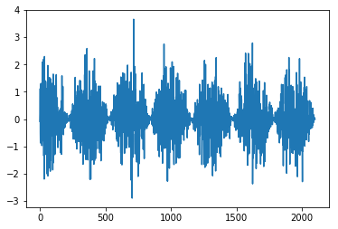

```python
# let's make some time series data!
data = np.cos(example)
data = np.array([t * np.random.normal() for t in data])
plt.plot(data)
data
```

```python
num_classes = 6
window_size=10
```

```python
# ... and take a window of the data to represent a single input step
def window(data,win_size,n):
    start = 0
    win = (data[start+n:win_size+n])
    plt.plot(win)
    return win
```

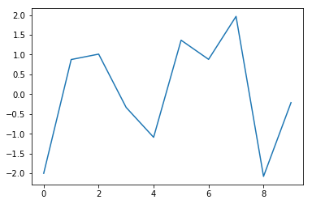

```python
window = window(data,window_size,53)
```

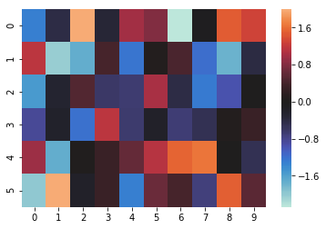

```python
# let's initialize our weight matrix (i.e., a gate within the lstm cell)
gate = np.zeros((num_classes,len(window)))

for r in range(len(gate[:,0])):
    for c in range(len(gate[0,:])):
        gate[r,c] = gate[r,c]+np.random.normal()

sns.heatmap(gate, center=0.0)
```

```python
# combine our input time step with the weight matrix
weighted_input = np.dot(gate, window)
# activate the matrix via sigmoid
sig_input = sigmoid(weighted_input)
# activate the matrix via tanh
tanh_input = tanh_3(weighted_input)
```

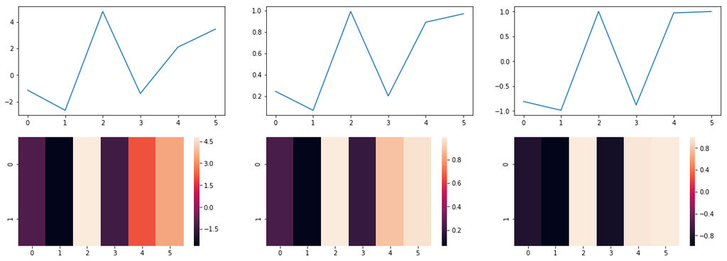

```python
# plot for comparison
plt.figure(figsize=(20,7))
plt.subplot(2,3,1)
plt.plot(weighted_input)
plt.subplot(2,3,4)
sns.heatmap((weighted_input,weighted_input))
plt.subplot(2,3,2)
plt.plot(sig_input)
plt.subplot(2,3,5)
sns.heatmap((sig_input,sig_input))
plt.subplot(2,3,3)
plt.plot(tanh_input)
plt.subplot(2,3,6)
sns.heatmap((tanh_input,tanh_input))
```

[output not shown]

# Learn to code an LSTM cell from scratch:

## See [Siraj Rival's LSTM YouTube video and the associated links](https://www.youtube.com/watch?v=9zhrxE5PQgY)!

## And check out [LSTMVis](http://lstm.seas.harvard.edu) from harvardnlp and Harvard's Visual Computing Group,

## As well as Andrej Karpathy's [LSTM blog post](http://karpathy.github.io/2015/05/21/rnn-effectiveness/)

# "Using Long Short-Term Memory Recurrent Neural Networks"

### 1) The "What"

### 2) The "Why"

# "Using Long Short-Term Memory Recurrent Neural Networks"

### 2) The "Why"

|  | Classical methods | DL/AI |
| --- | --- | --- |
| Pre-processing | + Smooth; Remove noise, gravity component, etc. + Use many sensors and channels (e.g., gyroscope, magnetometer) | + Keep to a minimum + Standardize data |
| Feature Extraction | + Generate many hand-crafted features (e.g., 551 for the HAR dataset) | + Let the network do this for you |
| Learning Algorithm | + Many to chose from + Depedent on parameter choice | + Optimize hyperparams + Parameters are learned from the data |

# "Using Long Short-Term Memory Recurrent Neural Networks"

### 2) The "Why"

### Both Classical and NN/AI methods have been shown to perform well,

### But, given the trending goal of online and on-device classification, can we agree that NNs deserve some attention?!

# "Using Long Short-Term Memory Recurrent Neural Networks"

### 2) The "What"

### 2) The "Why"

### 3) The "How"

[figure not shown]

# "Using Long Short-Term Memory Recurrent Neural Networks"

### 3) The "How" - Data Processing

| _ | _ |
| --- | --- |
| + Sliding window + Batch size +Step size |  |

# "Using Long Short-Term Memory Recurrent Neural Networks"

### 3) The "How" - Hyperparameters, Architectures

| Category | Hyperparameter |
| --- | --- |
| Architecture | Units Layers |
| Forward processing | Activation Function Bias Weight Init |
| Regularization | Gradient clipping Dropout Batch Normalization |
| Learning | Optimizers Learning Rate |

### ... And now to put it all together ...

# "Developing a Start-to-Finish Pipeline"

#### (for the aforementioned data and models)

# "Developing a Start-to-Finish Pipeline"

#### (for the aforementioned data and models)

## GOAL 1: UNIFY previous works and STANDARDIZE future work

## GOAL 2: Provide POC for optimized Baseline LSTM on *only* semi-raw trixial accelerometer data

# Breakdown of Related Works:

#### Over 30 studies analyzed

# Breakdown of Related Works:

#### Each used a **unique implementation** of LSTMs for HAR using Accelerometer data

# Breakdown of Related Works:

#### Each used a unique implementation of LSTMs for HAR using Accelerometer data

[figure not shown]

# Breakdown of Related Works:

#### Each used a unique implementation of LSTMs for HAR using Accelerometer data

[figure not shown]

# Breakdown of Related Works:

#### Each used a unique implementation of LSTMs for HAR using Accelerometer data

#### Multivariate Fully Convolutional LSTM

[figure not shown]

# Breakdown of Related Works:

#### Each used a unique implementation of LSTMs for HAR using Accelerometer data

[figure not shown]

# Breakdown of Related Works:

#### Each used a unique implementation of LSTMs for HAR using Accelerometer data

#### Deep Residual Bidirectional LSTMs

[figure not shown]

# Breakdown of Related Works:

#### Each used a unique implementation of LSTMs for HAR using Accelerometer data

#### Hierarchical LSTMs

[figure not shown]

# Breakdown of Related Works:

#### Each used a unique implementation of LSTMs for HAR using Accelerometer data

#### Ensemble LSTMs

[figure not shown]

# Breakdown of Related Works:

#### Each used a unique implementation of LSTMs for HAR using Accelerometer data

#### Meanwhile, some are still asking, do LSTMs even make sense to use?

[figure not shown]

# Breakdown of Related Works:

### Research into the *functioning* of LSTMs for classifying accelerometer data is very sparse

### This sort of research for LSTMs has mainly been done for text processing

[figure not shown]

# Breakdown of Related Works:

### Within the LSTM layers, the hyperparameter settings were all across the board

- Many provided little to no justification for there choice
- Those who did test over a range of hyperparameters used small ranges that did not overlap with ranges used by others

# Breakdown of Related Works:

### Within the LSTM layers, the hyperparameter settings were all across the board

- Meanwhile, one study used fANOVA to find that certain hyperparameter settings *do* affect the outcomes
- Many of the settings matched those optimized for text processing, but might they be different for accelerometer-based HAR?

# Breakdown of Related Works:

### Within the LSTM layers, the hyperparameter settings were all across the board

| Hyperparam | Range found in Lit |
| --- | --- |
| n Layers | 1, 2, 3, 4 |
| units per layer | 3 - 512 |
| recurrent activation fnxn | sigmoid* |
| cell output activation fnxn | tanh* relu sigmoid softmax linear |
| weight init | random orthogonal, fixed random seed, Glorot uniform, random uniform on [-1, 1], random normal distribution |
| mini batch sizes | 32 - 450 |
| loss fnxn | categorical cross entropy, F1 score loss, MSE, MAE |
| optimization | RMSprop, Adam, Adagrad, Nadam, Adadelta |
| learning rate | 1e−7,1e−6,1e−5,1e−4,1e−3,1e−2,1e−1 |
| regularization schemes | weight decay, dropout, momentum, gradient clipping, batch normalization |
| epochs | 10-10000 with early stopping |
| sliding winow size | 32 - 5000 ms |

# Breakdown of Related Works:

### Within the LSTM layers, the hyperparameter settings were all across the board

| Hyperparam | Range found in Lit |
| --- | --- |
| n Layers | 1, 2, 3, 4 |
| units per layer | 3 - 512 |
| recurrent activation fnxn | sigmoid* |
| cell output activation fnxn | tanh* relu sigmoid softmax linear |
| weight init | random orthogonal, fixed random seed, Glorot uniform, random uniform on [-1, 1], random normal distribution |
| mini batch sizes | 32 - 450 |
| loss fnxn | categorical cross entropy, F1 score loss, MSE, MAE |
| optimization | RMSprop, Adam, Adagrad, Nadam, Adadelta |
| learning rate | 1e−7,1e−6,1e−5,1e−4,1e−3,1e−2,1e−1 |
| regularization schemes | weight decay, dropout, momentum, gradient clipping, batch normalization |
| epochs | 10-10000 with early stopping |
| sliding winow size | 32 - 5000 ms |

# Breakdown of Related Works:

## Unifying the Field with Bayesian Optimization

[figure not shown]

## More on this later...

# Breakdown of Related Works:

### All kinds of preprocessing methods were used

- Nadaraya-Watson kernel weighted avg with Epanachnikov quadratic kernel and 40 nearest-neight window size
- remove gravity acceleration by applying median filter of length 2sec to each dimension and subratcting result
- construct movement borders (re hand orientation) via derivative of previously extracted gravity signals and calculating vector magnitude)

# Breakdown of Related Works:

### And many used additional data

| Gyroscope | Magnetometer |
| --- | --- |

# But wouldn't it be neat if we could just use triaxial accelerometer data?

### Less data to store, transfer, process...

### Puts the burden on the model !

## More on this later...

# Breakdown of Related Works:

### HAZARD: Data Leakage

[figure not shown]

# Breakdown of Related Works:

### Results: The Strong vs. The Weak

CV, Repeated Experiments ... vs. ... Single Best Result

[figure not shown]

# Methods

[figure not shown]

# The data ...

- UCI HAR Dataset
  - Used only the triaxial accelerometer data
  - 30 volunteers
  - Each performed 6 motor activities
    - Walking, Upstairs, Downstairs, Sittinng, Standing, Layinng
    - Recorded in a single time series with ~650,000 time steps
  - Accelerometer: embedded accelerometer in iPhone, worn on hip
  - https://archive.ics.uci.edu/ml/datasets/human+activity+recognition+using+smartphones

# First off, let's fix this formatting ...

- The data is provided pre-windowed and pre-split into test/train sets

# First off, let's fix this formatting ...

[figure not shown]

## Now let's optimize this network

## Now let's optimize this network

- With millions of possible hyperparameter configurations, grid search with packages like `GridSearchCV` from `scikit-learn` won't do ...
- We need some **heuristics** to help speed the search!

## Modeling the search space (i.e., data science)

[figure not shown]

## Now let's optimize this network

### Tree-Structured Parzen Estimators, implemented via `Hyperas` from `Hyperopt`

#### An Expected Improvement algorithm

## Now let's optimize this network

### Tree-Structured Parzen Estimators, implemented via `Hyperas` from `Hyperopt`

#### An Expected Improvement algorithm

### Based on [Algorithms for Hyper-Parameter Optimization](https://papers.nips.cc/paper/4443-algorithms-for-hyper-parameter-optimization.pdf) from Bergstra, *et. al.*, published in NIPS 2011 Proceedings

### This [blog](https://towardsdatascience.com/a-conceptual-explanation-of-bayesian-model-based-hyperparameter-optimization-for-machine-learning-b8172278050f) is great!

# Tree-Structured Parzen Estimators

[figure not shown]

### Tree-Structured Parzen Estimators

- Builds a probability model of the objective (loss) function:

[figure not shown]

  + so as to approximate

[figure not shown]

- Keep track of the past and become increasingly "less wrong" with hyperparameter choices

[figure not shown]

## Now let's optimize this network

### Tree-Structured Parzen Estimators, implemented via `Hyperas` from `Hyperopt`

## Basic Components of Sequential Model-Based Optimization (SMBO)

- **domain** of hyperparameters (search space)
  - probability distributions of each hyperparameter
  - start as uniform, log uniform, Gaussian, etc.
- **objective function** to minimize (loss function)
- **surrogate model** of the objective function
  - response surface
  - TPE: Baye's Theorem!
- **criteria for selecting** hyperparameters (selection function)

[figure not shown]

- **history** of previous trials

## Now let's optimize this network

### Tree-Structured Parzen Estimators, implemented via `Hyperas` from `Hyperopt`

#### An Expected Improvement algorithm

## TPE:

- group the hyperparameters into **tree-like structure** to represent commonality (category)
  - contruct probability distribution for each
    - e.g., one distr. over each layer
      - individual hyperparams within each layer
- TPE uses a **threshold** "best" performance
- and constructs **two different probability distributions** for a given hyperparameter combination:
  - one that is worse than this threshold
  - one that is better

### Tree-Structured Parzen Estimators, implemented via `Hyperas` from `Hyperopt`

[output not shown]

## Now let's optimize this network

### Tree-Structured Parzen Estimators, implemented via `Hyperas` from `Hyperopt`

#### An Expected Improvement algorithm

[figure not shown]

## Now let's optimize this network

### Tree-Structured Parzen Estimators, implemented via `Hyperas` from `Hyperopt`

#### An Expected Improvement algorithm

[figure not shown]

## Now that we've prepared our data and optimized our network, let's throw it all into a reproducible Pipeline

## Now that we've prepared our data and optimized our network, let's throw it all into a reproducible Pipeline

[figure not shown]

### A Note on Performance Measures: Don't be fooled by the Accuracy Paradox!

- Multiclass predictions:
  - Each class has its TP, TN, FP, FN
- Micro- vs. Macro- performance measures
  - Macro- computes the PM for each class and averages
  - Micro- aggregates the stats from each class and then computes a single PM (accounts for class imbalance!)
- **F1 Score** takes into account **Recall** and **Precision**
  - i.e., how many of the relevant items did we predict, and how many of the items we predicted were relevant, respectively
  - more robust than accuracy

# Results:

[figure not shown]

# Key Takeaways:

- LSTM's have great potential for online on-device Human Activity Recognition from raw accelerometer data alone
- We still have a lot to learn about LSTM cells' specific functioning when processing accelerometer data
- As such, case-wise model optimization is important!
- Additionally, we should be reporting the parameters we use, the ranges we test over, our reasoning and justifications thereof
- CV yields robust results; micro-F1 Score is more robust than Accuracy
- Pipelines allow reproducibility

The code: https://github.com/xtianmcd/accelstm